# I migliori 1000 film secondo IMDB

IMDb, acronimo di Internet Movie Databes, fondato nel 1990, rappresenta il più grande database online dedicato al cinema. Contiene informazioni complete su tutti i dati d'interesse relativi al cinema, come film, serie TV, registi, attori, sceneggiatori, produttori e altre figure dell'industria.

### Motivazioni:

- Passione per il cinema;
- Curiosità;
- Interesse personale;
- Ricerca di tendenze;

### Domande a cui rispondere:

- Quali sono i generi più rappresentati?
- Qual è il numero di film usciti per ogni decennio?
- Qual è l'andamento della valutazione e della durata media dei film nel corso dei decenni?
- Esiste una correlazione tra durata e valutazione?
- Qual è l'andamento degli incassi e quali sono i 10 film che hanno generato più guadagni?
- Quali sono i 10 film con una valutazione migliore?
- Quali sono i primi 5 registi per numero di film migliori?

## Il dataset

Il dataset utilzzato è il seguente: [Top 1000 IMDB](https://www.kaggle.com/datasets/harshitshankhdhar/imdb-dataset-of-top-1000-movies-and-tv-shows)

Il dataset è stato creato nel 2021, mancano perciò i dati relativi ai film usciti negli ultimi 3 anni.

Contiene dati molto interessanti e utili per analizzare diverse tendenze, manca però il dato sull'età minima per vedere un film.

### I dati

- Poster_link: link di reindirizzamento per la visione;
- Series_Title: titolo del Film;
- Released_Year: anno di uscita;
- Certificate: certificazione del film;
- Runtime: durata in minuti;
- Genre: generi;
- IMDB_Rating: valutazione su IMDb;
- Overview: breve descrizione del film;
- Metascore: valutazione della critica;
- Director: regista;
- Star: attori principali;
- No_of_Votes: numero di voti;
- Gross: incasso;

## I generi più rappresentati

Attenzione: un film può contenere più generi.

Si nota come il genere 'Drama' sia nettamente in testa rispetto agli altri, apparendo 724 volte. A livello percentuale però, come sono distribuiti i primi 5 film per genere?

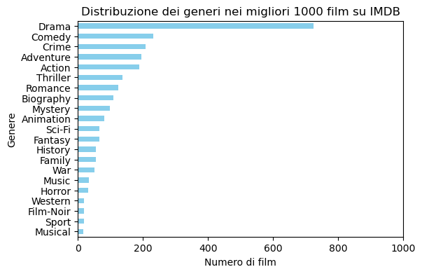

### Distribuzione in percentuale dei top 5 generi

A livello percentuale però, come sono distribuiti i primi 5 film per genere?

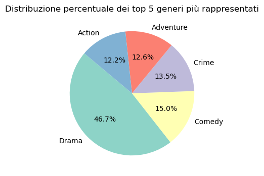

## Numero di film usciti per decennio

Si nota come dal 1980 in poi la produzione di film sia aumentata esponenzialmente .

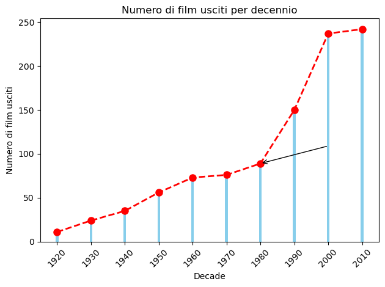

### Distribuzione dei film prima e dopo il 2000

Il grafico a torta rende evidente come in proporzione la produzione di film dopo il 2000 sia aumentata notevolmente, grazie sopratutto al miglioramento delle tecnologie.

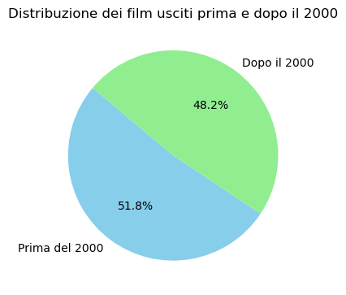

## Valutazione e durata media

### Valutazione media

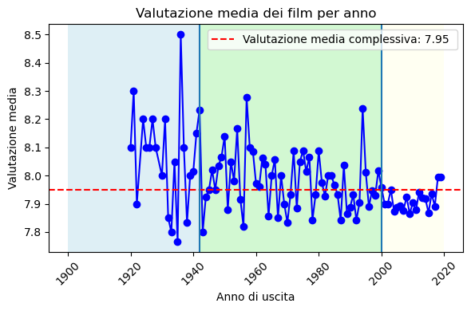

### Durata media

La durata dei film è quindi aumentata nel corso degli anni. Viene ora da chiedersi se esiste una correlazione tra durata e valutazione.

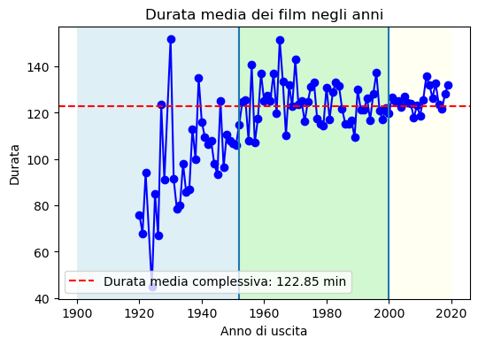

## Correlazione tra durata e valutazione

Esiste quindi un correlazione debole (0.24) tra durata e valutazione. All'aumentare della durata si ha un lieve aumento della valutazione, ma la correlazione non è abbastanza forte per essere considerata predittiva.

La durata è quindi solo uno dei tanti fattori che concorrono alla valutazione finale.

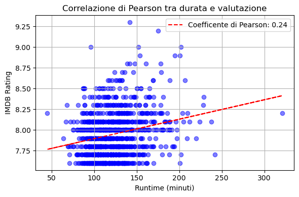

## Andamento degli incassi

Si è visto come la produzione di film sia aumentata esponenzialmente dal 1980 ad oggi. Viene naturale domandarsi se anche gli incassi siano aumentati nella medesima proporzione.

Il grafico mostra come anche gli incassi seguano il "modello esponenziale" di crescita dal 1980 in poi

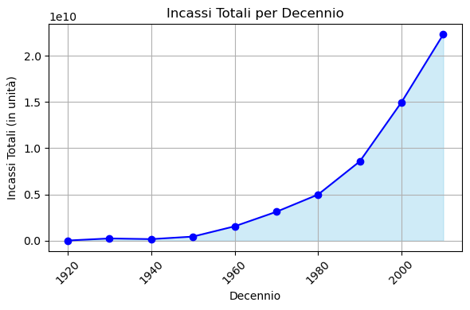

## Migliori dieci film per incassi

E' interessante notare come tutti i film presenti nel grafico siano posteri al 2000, escluso Titanic.

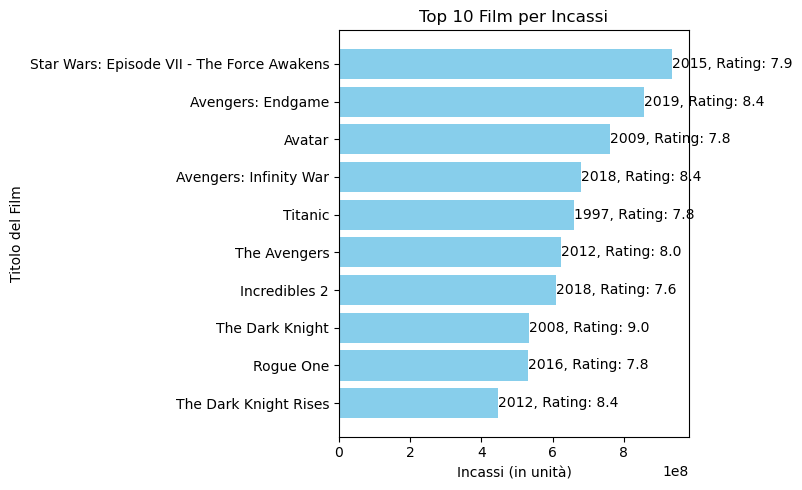

## 10 film con una valutazione migliore

Dei seguenti film possiamo notare come solo 3 film siano usciti dal 2000 in poi, dimostrando come all'aumentare della produzione di film non è detto che aumenti la qualità del prodotto.

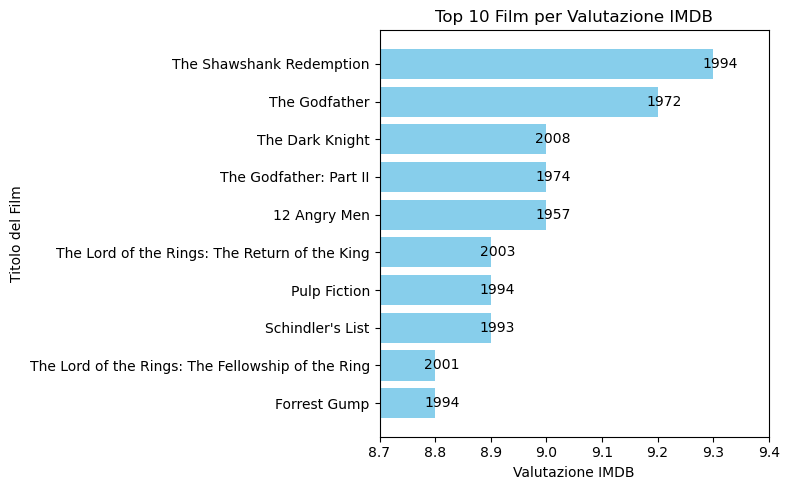

## I migliori 5 registi

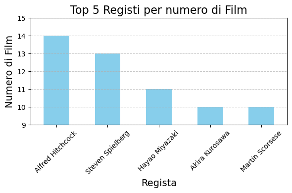

## Conclusioni

Dall'analisi del dataset si possono trarre le seguenti conclusioni:

- Il genere decisamente più comune è il Drama;
- Il numero di film è aumentato esponenzialmente dal 1980 in poi;
- La durata media dei film è aumentata nel corso del tempo;
- La valutazione media non mostra una tendenza chiara, ma può comunque essere suddivisa in tre periodi;
- Esiste una correlazione debole tra durata e valutazione;
- Gli incassi sono aumentati conseguentemente all'aumentare della produzione, e i migliori 10 film per incassi sono stati prodotti quasi tutti dopo il 2000;

L'obiettivo di andare alla ricerca di tendenza è stato quindi soddisfato, permettendo così di effettuare una panoramica generale sul mondo del cinema attraverso i dati.